# Bayesian Survival Analysis of Veteran Lung Cancer Patients: A Comparison of Weibull and Exponential Models

- Adeno shifts downward in survival time once adjusted — suggesting that some of the unadjusted advantage in the first plot might be due to patient characteristics.
- The x-axis has shifted to the right, showing longer survival times:
  - Before adjustment: medians were ~10–60 days.
  - After adjustment: medians now range from ~50 to over 200 days.

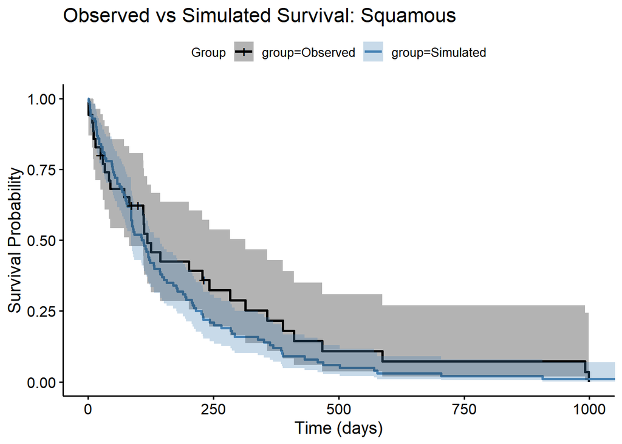

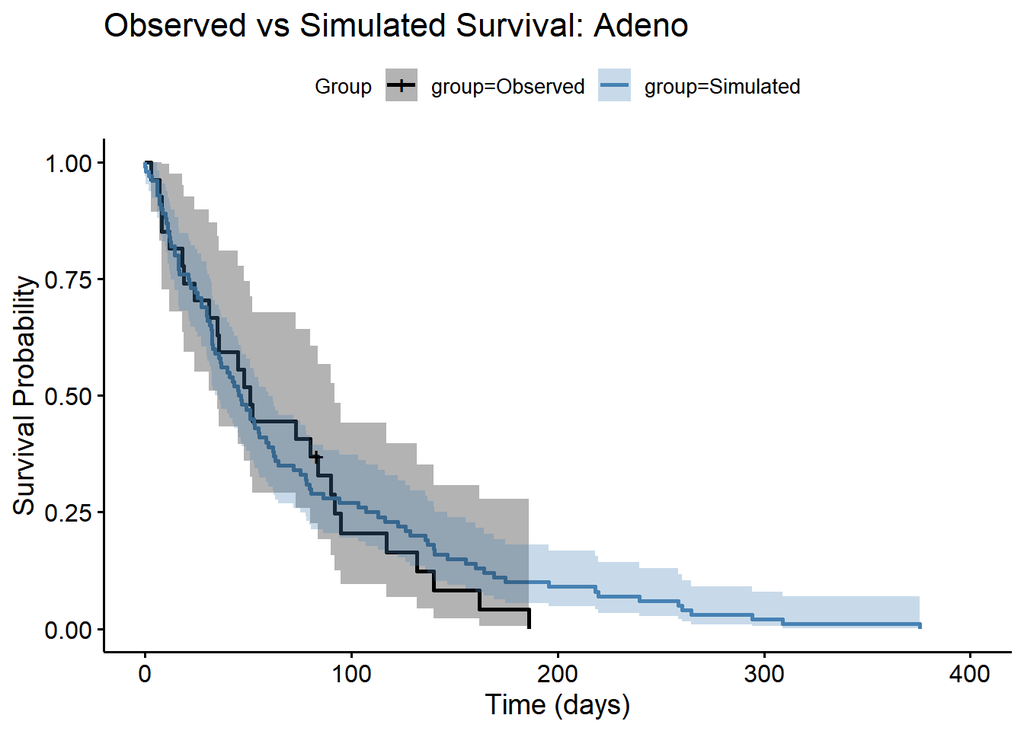

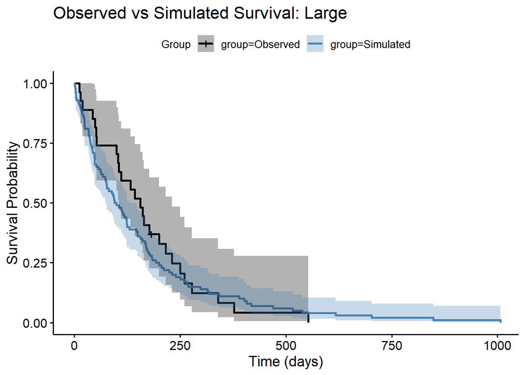

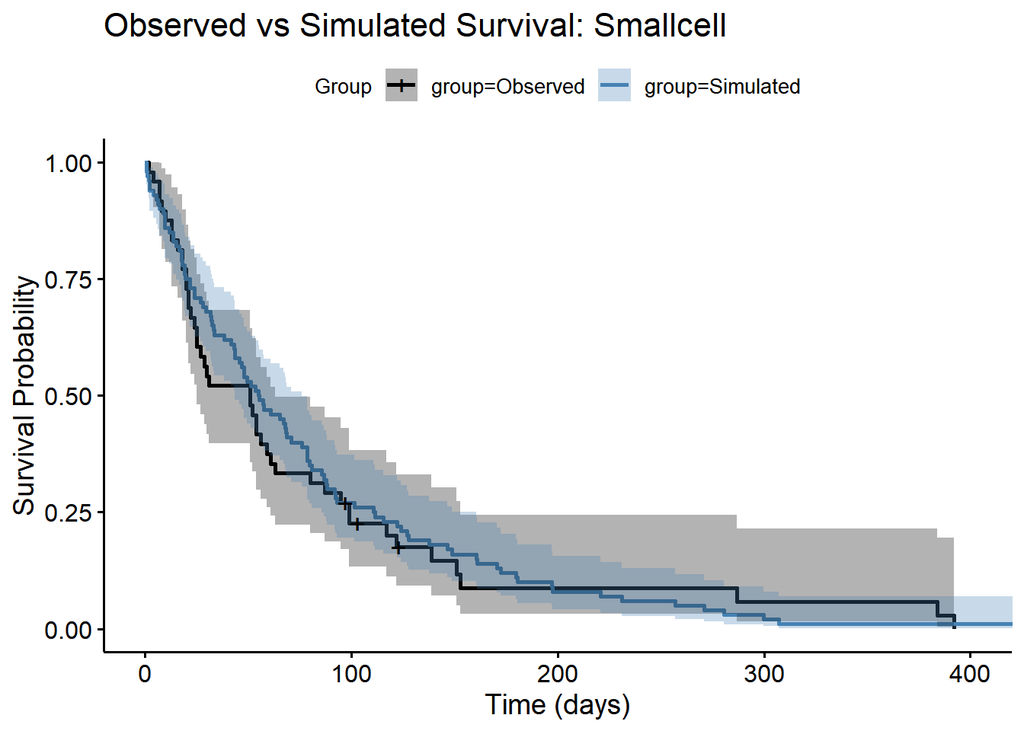

- **Squamous**: The model fits quite well
- **Adeno**: The model overpredicts survival — simulated patients live longer on average than observed. Indicates the exponential assumption may be too rigid for early drop-off seen in Adeno.
- **Large**: The model underpredicts survival — simulated patients die earlier. Possibly the exponential model can’t capture the slower decline in observed survival.
- **Smallcell**: Model fits moderately well, but again a bit optimistic (simulated curve above observed).

```r
#traceplot(exp_complete_AFT_samples)

# Output removed but explained later to preserve a clean notebook
```

```
## Potential scale reduction factors:
##
##         Point est. Upper C.I.
## beta[1]       1.06       1.18
## beta[2]       1.01       1.02
## beta[3]       1.00       1.01
## beta[4]       1.00       1.01
## beta[5]       1.03       1.10
## beta[6]       1.03       1.11
## beta[7]       1.00       1.01
## beta[8]       1.00       1.01
## beta[9]       1.00       1.01
##
## Multivariate psrf
##
## 1.04
```

**Concerning Trace Plot**:

Posterior uncertainty for baseline survival time is still large, likely due to high variability in the squamous group.

Age effect on log-survival time is subtle and possibly confounded.

Posterior still converging, but slower than others. Could benefit from more iterations or thinning.

**Well-Converged Parameters:**

beta[2], beta[3], beta[4], beta[7], beta[8], beta[9]

These parameters appear to be well-mixed and stationary:

Trace plots are flat and overlapping.

This indicates that collectively, the parameters are close to convergence, but some dimensions (like beta[1], beta[5]) need more iterations to achieve reliable joint posterior exploration.

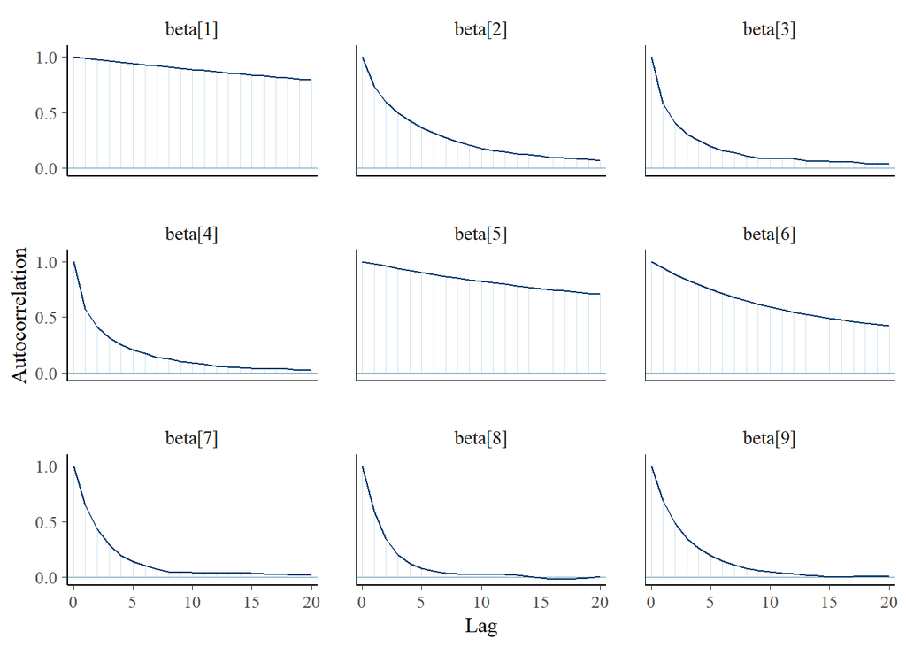

Parameters like beta[1], beta[5], beta[6] exhibit strong autocorrelation even at higher lags.

This suggests that the chain is moving slowly, in fact for those:

```
##    beta[1]    beta[2]    beta[3]    beta[4]    beta[5]    beta[6]    beta[7]
##   91.63966 1441.47244 2431.12439 2368.15744  154.41865  355.79555 3003.49361
##    beta[8]    beta[9]
## 3928.77525 2558.95198
```

The effective sample size (ESS) is low despite many iterations.

```
## Manual DIC (Exponential AFT with covariates): 1450.596
```

## Weibull Survival Model

The Kaplan–Meier analysis revealed that the hazard of death is **not constant over time**. Most patient groups show a steep risk increase early on, followed by a plateau. This pattern violates the constant hazard assumption of the **Exponential model**.

To better model this behavior, we use the **Weibull distribution**, a flexible parametric model that allows the hazard to either increase or decrease with time.

**The Weibull Distribution**

Let $T$ denote the survival time. The Weibull distribution is defined by two parameters: - $\lambda > 0$: scale  
- $\kappa > 0$: shape

It has the following mathematical form:

- **Probability density function (PDF):**
  $$f(t \mid \lambda, \kappa) = \kappa \lambda t^{\kappa - 1} \exp(-\lambda
  t^\kappa)$$
- **Survival function:**
  $$S(t \mid \lambda, \kappa) = \exp(-\lambda t^\kappa)$$
- **Hazard function:**
  $$h(t) = \frac{f(t)}{S(t)} = \kappa \lambda t^{\kappa - 1}$$

Interpretation of the shape parameter $\kappa$: - $\kappa = 1$: constant hazard → Exponential case  
- $\kappa > 1$: increasing hazard → aging, deterioration  
- $\kappa < 1$: decreasing hazard → early failure, treatment effect

**Weibull Regression Model – AFT Parametrization**

To include patient-level covariates (e.g., cell type, age, performance score), we use the **Accelerated Failure Time (AFT)** formulation:

$$\log(T_i) = \mu_i + \sigma \varepsilon_i, \quad \varepsilon_i \sim
\text{Gumbel}(0, 1)$$

where: - $\mu_i = \mathbf{x}_i^\top \beta$ is the linear predictor  
- $\sigma = 1 / \kappa$ is the AFT scale parameter

This corresponds to:
$$T_i \sim \text{Weibull}(\lambda_i, \kappa), \quad \text{with } \lambda_i
= \exp(-\mathbf{x}_i^\top \beta)$$

The AFT interpretation is intuitive:

> Covariates **accelerate or decelerate** survival time multiplicatively.

**Censoring and the Likelihood**

Right-censoring is common in survival data. We adapt the likelihood accordingly:

$$\mathcal{L}_i =
\begin{cases}
f(t_i) & \text{if the event is observed} \\
S(t_i) & \text{if right-censored}
\end{cases}$$

This framework fits naturally within a **Bayesian setting**, where censoring is easily handled in the model structure via latent event times and survival functions.

### Weibull Baseline Model (No Covariates)

```r
# Prepare data
weibull_data_baseline = list(
  time = veteran$time,
  isCensored = 1 - veteran$status,
  N = nrow(veteran),
  t = ifelse(veteran$status == 1, veteran$time, NA)  # known times or NA
)
```

```r
# Write JAGS model
cat("
model {
  for (i in 1:N) {
    isCensored[i] ~ dinterval(t[i], time[i])  # Handle censoring
    t[i] ~ dweib(shape, scale)
  }

  # weakly informative priors
  shape ~ dgamma(1, 0.1)
  scale ~ dgamma(1, 0.01)
}
", file = "weibull_intercept.jags")

# Since we want to model censored observations, we have to treat t[i] as a data node

# dweib() has a built-in censoring using dinterval() for right-censored data
```

```r
#run the model
model = jags.model("weibull_intercept.jags", data = weibull_data_baseline, n.chains = 3, n.adapt = 1000)
update(model, 1000)  # Burn-in
samples_weibull_baseline = coda.samples(model, variable.names = c("shape", "scale"), n.iter = 5000)
summary(samples_weibull_baseline)
```

```
##
## Iterations = 2001:7000
## Thinning interval = 1
## Number of chains = 3
## Sample size per chain = 5000
##
## 1. Empirical mean and standard deviation for each variable,
##    plus standard error of the mean:
##
##          Mean       SD  Naive SE Time-series SE
## scale 0.01914 0.005916 4.831e-05      0.0002563
## shape 0.83690 0.055972 4.570e-04      0.0025007
##
## 2. Quantiles for each variable:
##
##          2.5%     25%     50%     75%   97.5%
## scale 0.01002 0.01488 0.01824 0.02259 0.03268
## shape 0.72995 0.79843 0.83771 0.87496 0.94646
```

**Hazard Behavior: Shape Parameter $\alpha$ < 1 → Decreasing Hazard**

The shape parameter $\alpha$ in the Weibull distribution controls the hazard rate over time, as explained before. From our posterior samples:

Since the entire credible interval lies **below 1**, we have strong evidence of a **decreasing hazard rate**.

**Clinical interpretation:**

> The model suggests that the **risk of death is highest shortly after diagnosis**. Patients who survive the early critical period tend to have **improving survival prospects** over time.  
> This aligns well with the trends observed in the **Kaplan–Meier curves**, where survival drops steeply early on.

**Median Survival Time**

The **scale parameter $\lambda$** governs how “stretched” the survival times are along the time axis. It plays a key role in determining the **median survival time** using the formula:

Where: - $\lambda$: scale parameter  
- $\alpha$: shape parameter

Using the posterior means:

```
## [1] 73.03474
```

The resulting value is very low, indicating that the median survival time is short under the intercept-only model.

This shows us also the **Limitations of the Baseline Model**:

- This model treats all patients as identical, ignoring clinical heterogeneity
- The early deaths dominate the likelihood, pulling the median downward and making it an unstable summary.

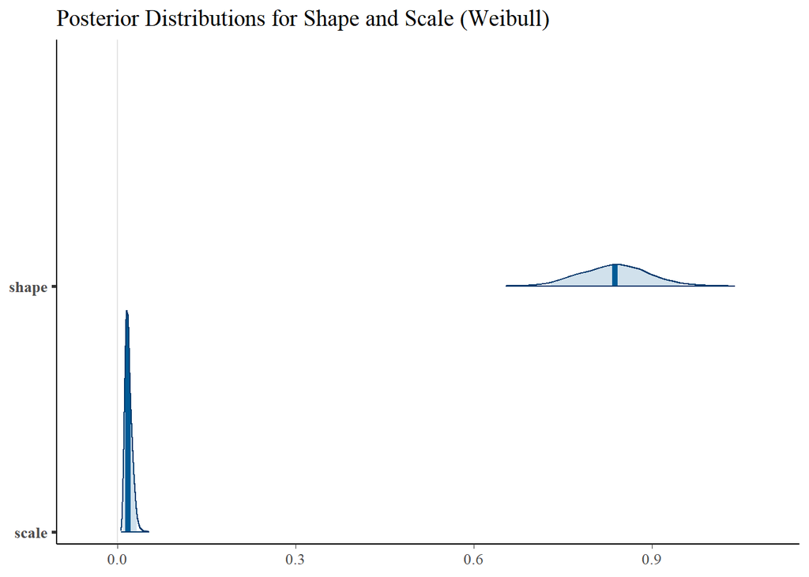

**Shape Parameter**

**Scale Parameter**:

- The **posterior for scale** is sharply peaked near zero, with most of the probability mass between **0 and 0.05**. This leads to the **unrealistically low median survival** estimates (as seen previously).

This reflects the **compressing effect** of the intercept-only model: since no covariates are included, the model compensates by squeezing the scale to explain rapid early deaths. The peakedness indicates the model is very confident in this (possibly misspecified) value — a classic sign that the model is too rigid

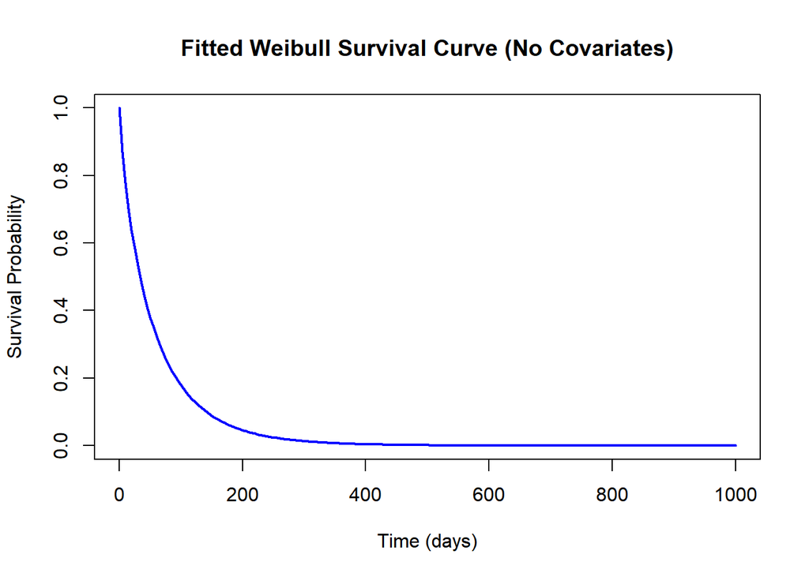

This is the **baseline survival** across all patients (No covariates included). The model-implied survival function confirms what Kaplan–Meier had shown: **rapid early decline**

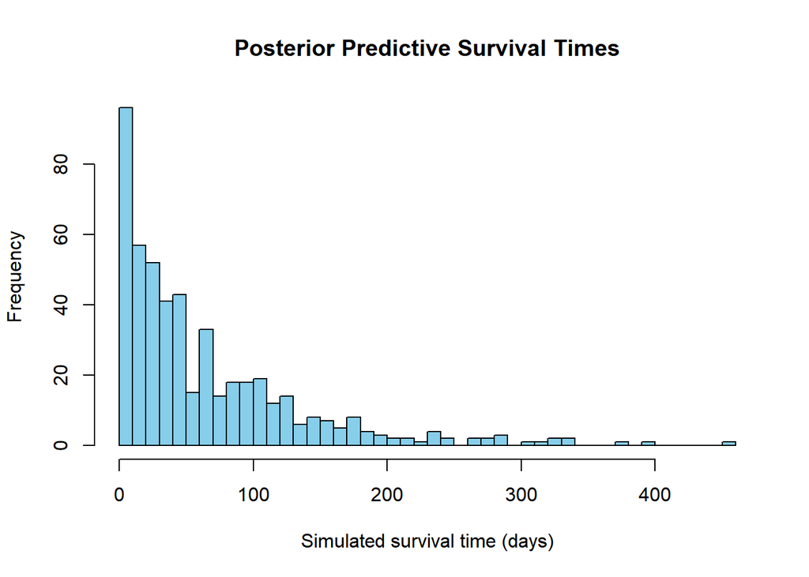

The histogram shows a heavy skew toward early deaths, with the majority of predicted lifespans falling under 100 days. This matches the structure of the observed data.

The long right tail includes rare simulations with survival > 300 days, reflecting posterior uncertainty and the long-tailed nature of the Weibull distribution with $\alpha < 1$.

The **mean survival time** for the baseline Weibull model is:

$$\mathbb{E}[T] = \frac{1}{\lambda} \cdot \Gamma\left(1 + \frac{1}{\kappa}
\right)$$

```
##    Min. 1st Qu.  Median    Mean 3rd Qu.    Max.
##   25.56   50.15   60.17   62.56   71.98  161.39
```

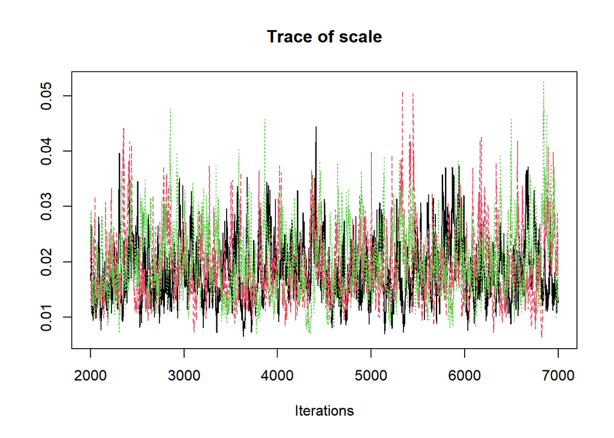

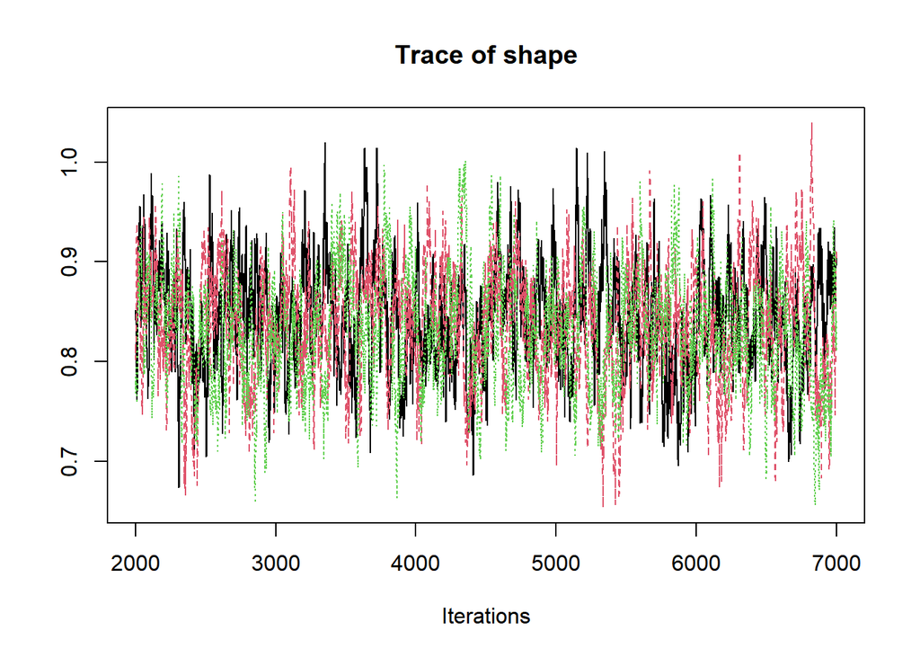

```
## Potential scale reduction factors:
##
##       Point est. Upper C.I.
## scale       1.01       1.03
## shape       1.01       1.02
##
## Multivariate psrf
##
## 1.01
```

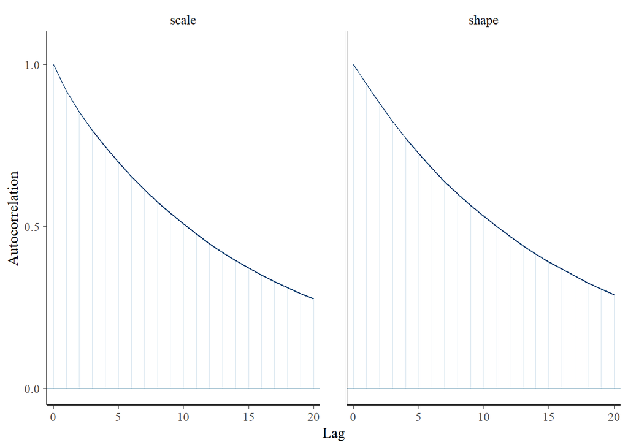

```
##    scale    shape
## 526.8884 496.5387
```

```
## Manual DIC (Weibull Baseline): 1729.418
```

**Why Did the Exponential Baseline Model Perform Better?**

Despite assuming a constant hazard, the exponential baseline model fit the data surprisingly well. This is because:

- **Early deaths dominate** the dataset, and a constant hazard can approximate that initial steep drop in survival.
- With **no covariates**, the model just estimates a global average rate — which can still match the overall event distribution.
- **Bayesian inference** smooths over model misspecification, favoring plausible parameters even in simple models.
- The **Weibull model**, while more flexible, can be skewed in intercept-only form due to lack of individual-level information.

### Weibull AFT Model with Tumor Cell Type

We now extend the baseline Weibull model by including **tumor cell type** as a categorical covariate. This allows the model to explain variation in survival time across cancer histologies.

We use the **Accelerated Failure Time (AFT)** formulation:

$$\log(T_i) = \mu_i + \sigma \varepsilon_i, \quad \varepsilon_i \sim
\text{Gumbel}(0,1)$$

Where: - $\mu_i = \beta_0 + \beta_1 X_{1i} + \beta_2 X_{2i} + \beta_3 X_{3i}$

- $\sigma = 1/\kappa$ is the scale parameter (inverse of Weibull shape)
- Covariates $X_{1i}, X_{2i}, X_{3i}$ encode tumor cell type via dummy variables

- $\beta_0$: log survival for `squamous`
- $\beta_1$: additional log-time for `smallcell` vs `squamous`
- $\beta_2$: for `adeno` vs `squamous`
- $\beta_3$: for `large` vs `squamous`

The model becomes:

This model interprets coefficients in terms of **survival time acceleration/deceleration**, not hazard ratios. For example:

- $\beta_j < 0$: **longer survival** than baseline
- $\beta_j > 0$: **shorter survival**

```r
X_celltype = model.matrix(~ celltype, data = veteran)
#levels(veteran$celltype)
#colnames(model.matrix(~ celltype, data = veteran))
weibull_data_AFT_tumor_type = list(
  N = nrow(veteran),
  time = veteran$time,
  isCens = 1 - veteran$status,
  X = X_celltype,
  K = ncol(X_celltype),
  t = rep(NA, nrow(veteran))
)
weibull_data_AFT_tumor_type$t = veteran$time
```

```r
cat("
model {
  for (i in 1:N) {
    isCens[i] ~ dinterval(t[i], time[i])
    t[i] ~ dweib(shape, lambda[i])

    mu[i] = inprod(beta[], X[i,])
    lambda[i] = exp(mu[i])
  }

  for (j in 1:K) {
    beta[j] ~ dnorm(0, 0.01)
  }

  shape ~ dgamma(1, 0.1)
}
", file = "weibull_aft_celltype.jags")
```

```r
model = jags.model("weibull_aft_celltype.jags", data = weibull_data_AFT_tumor_type, n.chains = 3, n.adapt = 1000)
update(model, 1000)
samples_weibull_AFT_tumor_type = coda.samples(model, variable.names = c("beta", "shape"), n.iter = 5000)
summary(samples_weibull_AFT_tumor_type)
```

```
##
## Iterations = 2001:7000
## Thinning interval = 1
## Number of chains = 3
## Sample size per chain = 5000
##
## 1. Empirical mean and standard deviation for each variable,
##    plus standard error of the mean:
##
##            Mean      SD  Naive SE Time-series SE
## beta[1] -5.2338 0.41830 0.0034154       0.027161
## beta[2]  1.0106 0.23525 0.0019208       0.007592
## beta[3]  1.1154 0.27346 0.0022328       0.008928
## beta[4]  0.1699 0.25675 0.0020964       0.005254
## shape    0.9869 0.06469 0.0005282       0.003809
##
## 2. Quantiles for each variable:
##
##            2.5%        25%     50%     75%   97.5%
## beta[1] -6.1253 -5.4947441 -5.2205 -4.9534 -4.4396
## beta[2]  0.5572  0.8510294  1.0072  1.1666  1.4845
## beta[3]  0.5774  0.9343145  1.1134  1.3019  1.6494
## beta[4] -0.3403  0.0007481  0.1728  0.3409  0.6778
## shape    0.8651  0.9434906  0.9851  1.0278  1.1183
```

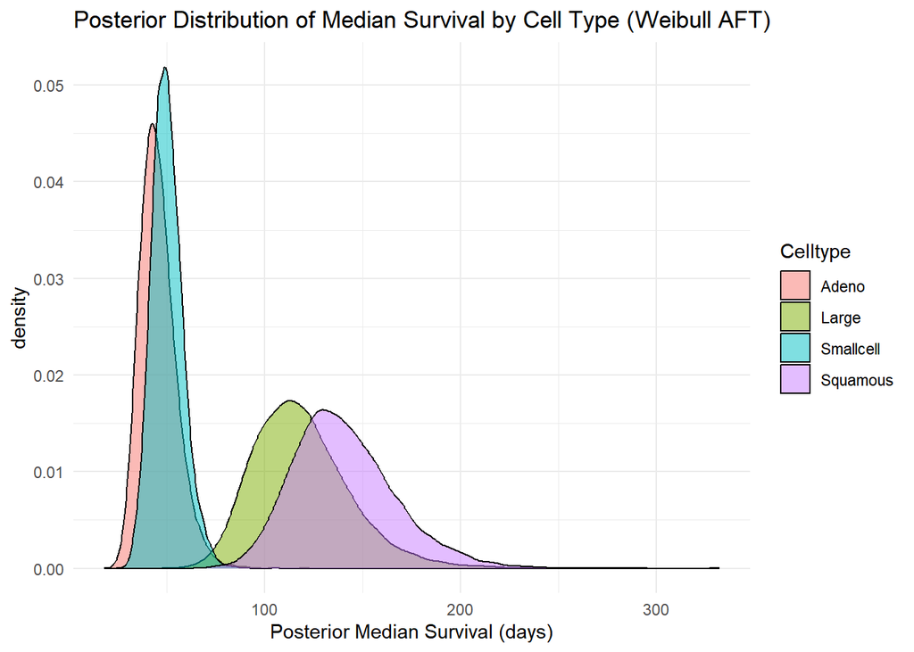

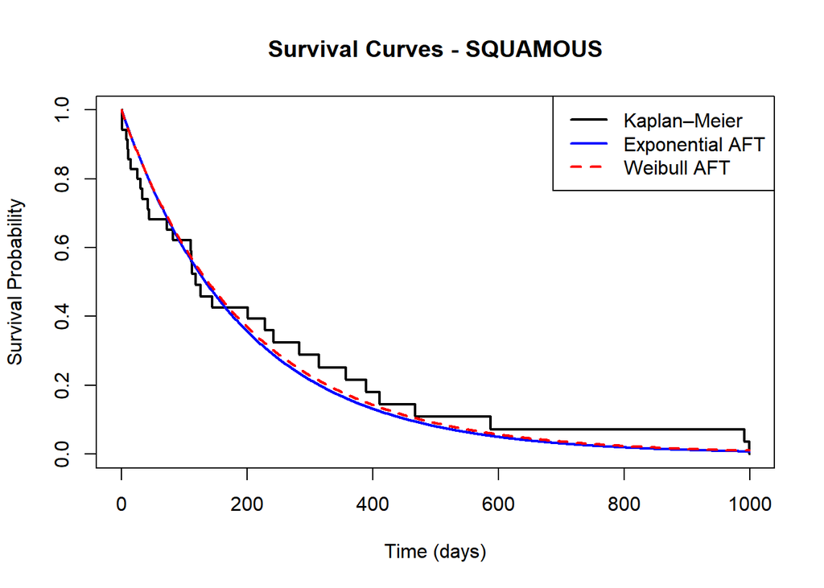

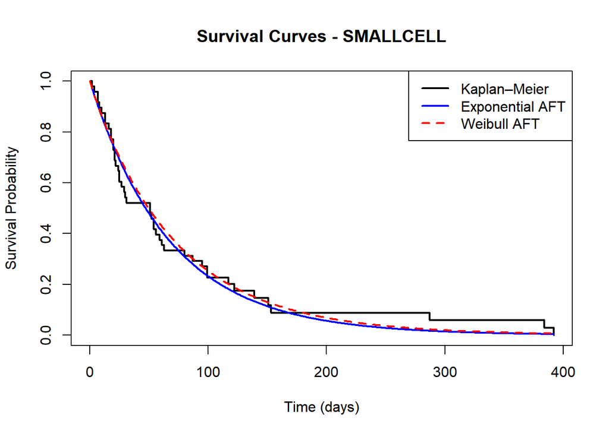

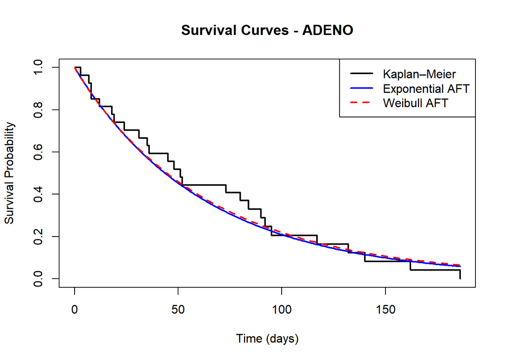

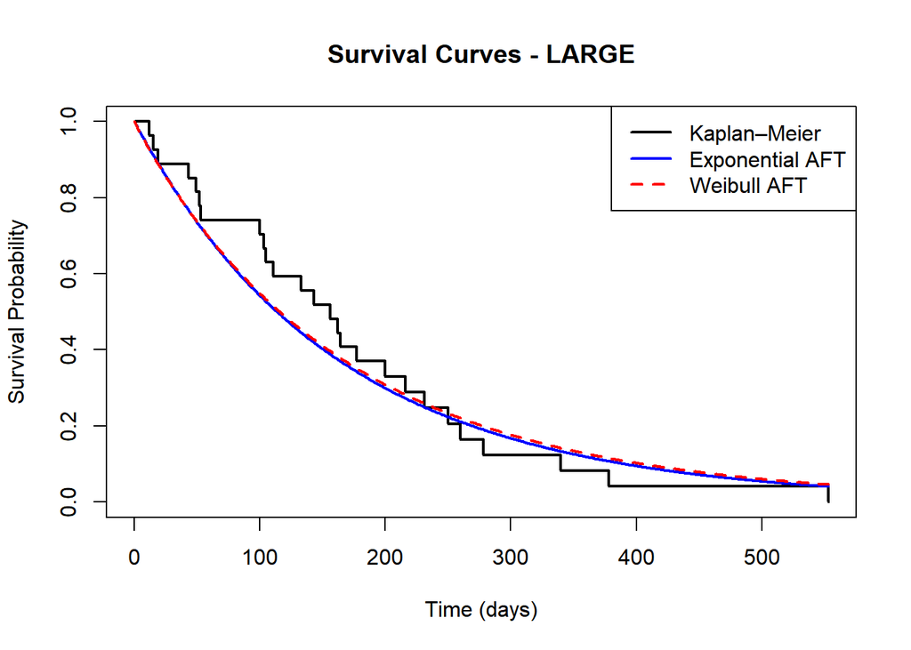

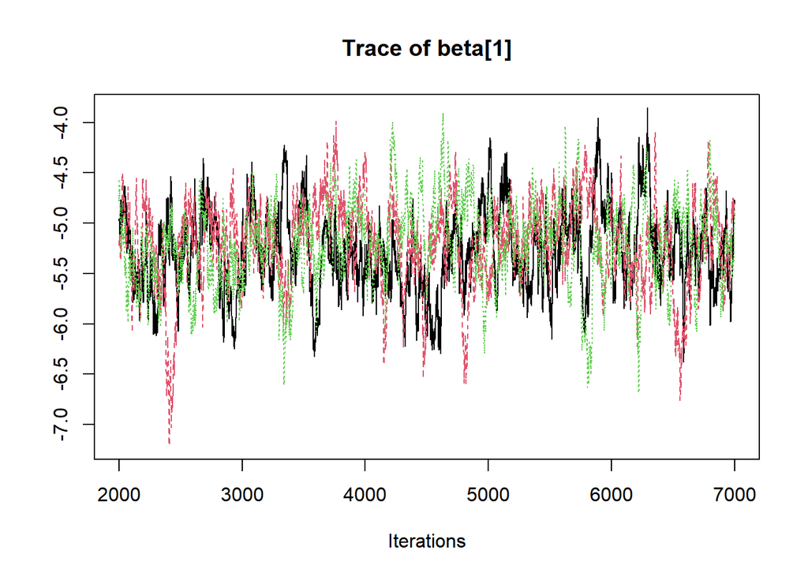

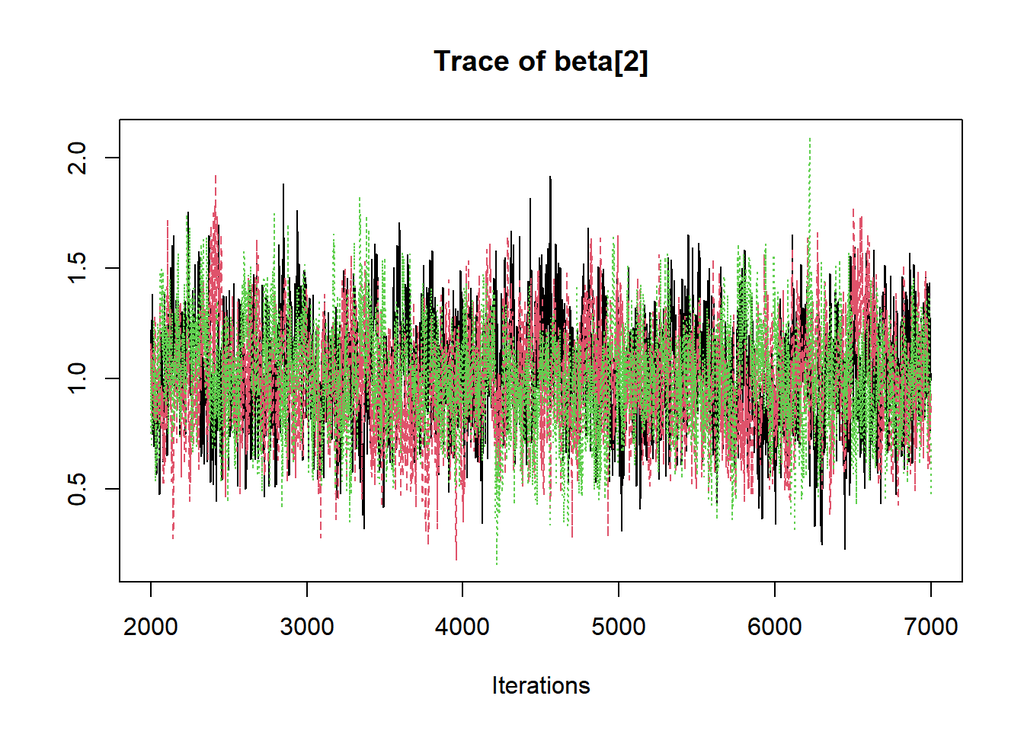

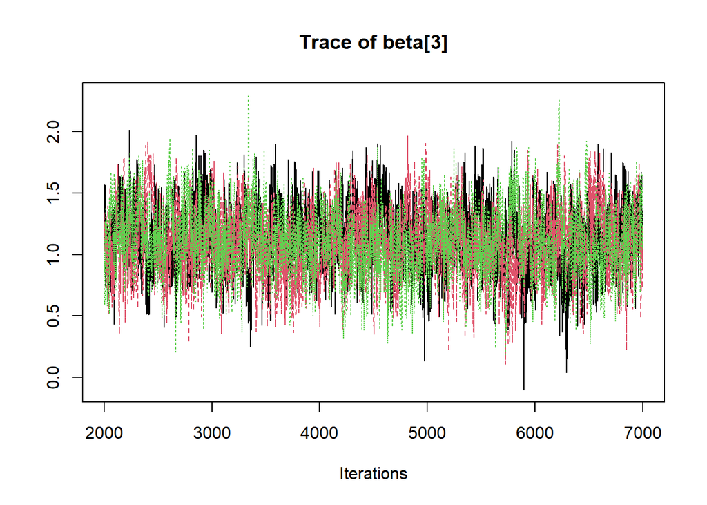

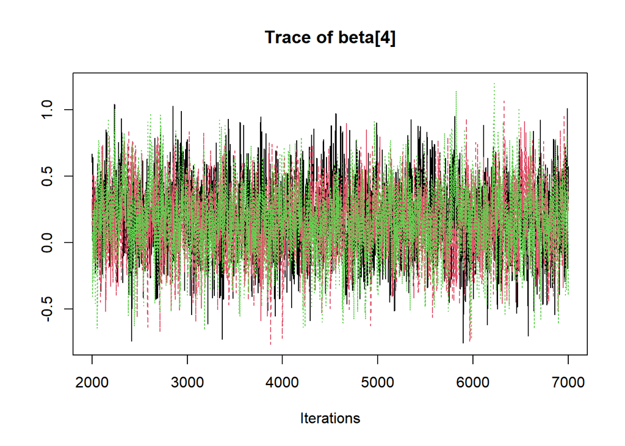

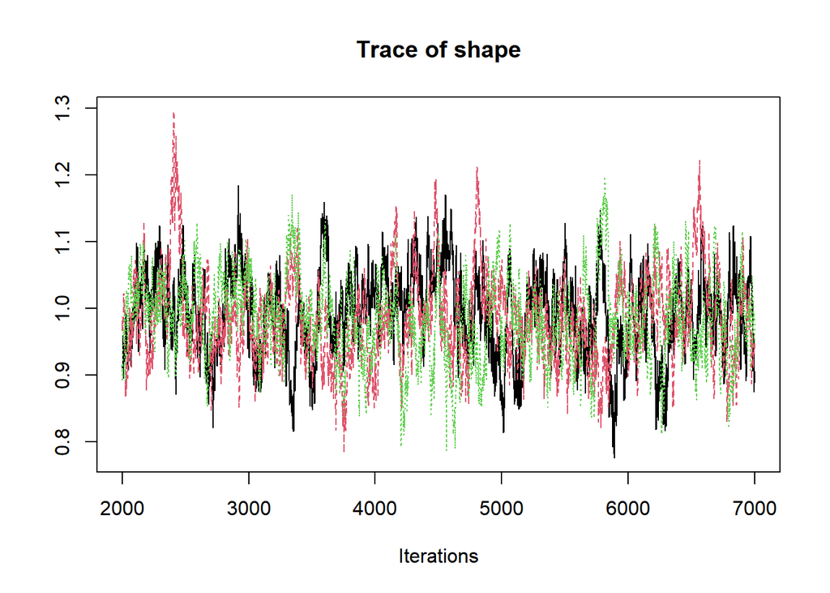

- **Trace plots** for show good mixing without drift or stickiness across chains, although some **minor stickiness** can be noticed for `beta[1]`.

```r
gelman.diag(samples_weibull_AFT_tumor_type)
```

```
## Potential scale reduction factors:
##
##         Point est. Upper C.I.
## beta[1]       1.02       1.08
## beta[2]       1.01       1.03
## beta[3]       1.01       1.03
## beta[4]       1.00       1.01
## shape         1.02       1.07
##
## Multivariate psrf
##
## 1.02
```

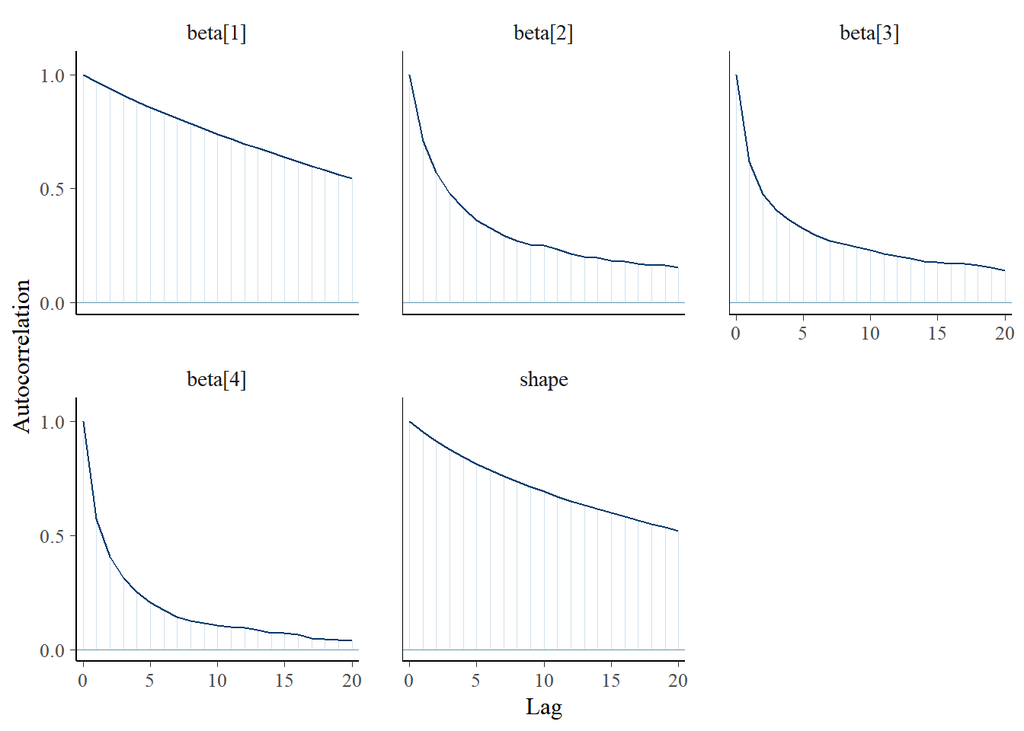

```
##   beta[1]   beta[2]   beta[3]   beta[4]     shape
##  237.4855  961.3260  960.0240 2422.9455  289.0189
```

Overall, convergence diagnostics are satisfactory

```
## Manual DIC (Weibull AFT with Celltype): 1503.735
```

### Weibull with All Covariates

```r
X = model.matrix(~ celltype + age + karno + diagtime + prior + trt, data = veteran)

weibull_data_nocensor = list(
  N = nrow(veteran),
  K = ncol(X),
  X = X,
  t = veteran$time
)
```

```r
cat("
model {
  for (i in 1:N) {
    t[i] ~ dweib(shape, lambda[i])

    mu[i] = inprod(beta[], X[i,])
    lambda[i] = exp(mu[i])
  }

  for (j in 1:K) {
    beta[j] ~ dnorm(0, 0.01)
  }

  shape ~ dgamma(1, 0.1)
}
", file = "weibull_aft_fullcov_nocensor.jags")
```

```r
model = jags.model("weibull_aft_fullcov_nocensor.jags", data = weibull_data_nocensor, n.chains = 3, n.adapt = 1000)
update(model, 1000)
samples_weibull_nocensor = coda.samples(model, variable.names = c("beta", "shape"), n.iter = 5000)
summary(samples_weibull_nocensor)
```

```
##
## Iterations = 2001:7000
## Thinning interval = 1
## Number of chains = 3
## Sample size per chain = 5000
##
## 1. Empirical mean and standard deviation for each variable,
##    plus standard error of the mean:
##
##              Mean       SD  Naive SE Time-series SE
## beta[1] -3.553337 0.733660 5.990e-03      0.0773270
## beta[2]  0.866998 0.269582 2.201e-03      0.0084053
## beta[3]  1.161299 0.292140 2.385e-03      0.0081834
## beta[4]  0.332966 0.277360 2.265e-03      0.0066082
## beta[5] -0.006877 0.008638 7.053e-05      0.0006534
## beta[6] -0.030007 0.005269 4.302e-05      0.0002589
## beta[7] -0.002054 0.009211 7.521e-05      0.0001657
## beta[8]  0.057823 0.222332 1.815e-03      0.0036739
## beta[9]  0.218827 0.202314 1.652e-03      0.0044682
## shape    1.082007 0.069706 5.691e-04      0.0038355
##
## 2. Quantiles for each variable:
##
##             2.5%      25%       50%       75%    97.5%
## beta[1] -5.08923 -4.01714 -3.516578 -3.041639 -2.19754
## beta[2]  0.33599  0.68809  0.867111  1.046005  1.40301
## beta[3]  0.58850  0.96436  1.164450  1.355118  1.73050
## beta[4] -0.20929  0.14627  0.334810  0.520980  0.87926
## beta[5] -0.02319 -0.01286 -0.007149 -0.001231  0.01102
## beta[6] -0.04018 -0.03361 -0.030061 -0.026428 -0.01950
## beta[7] -0.02143 -0.00792 -0.001633  0.004280  0.01461
## beta[8] -0.37900 -0.09149  0.058758  0.207484  0.48990
## beta[9] -0.18225  0.08640  0.216575  0.355075  0.61824
## shape    0.94720  1.03451  1.081646  1.127343  1.22396
```

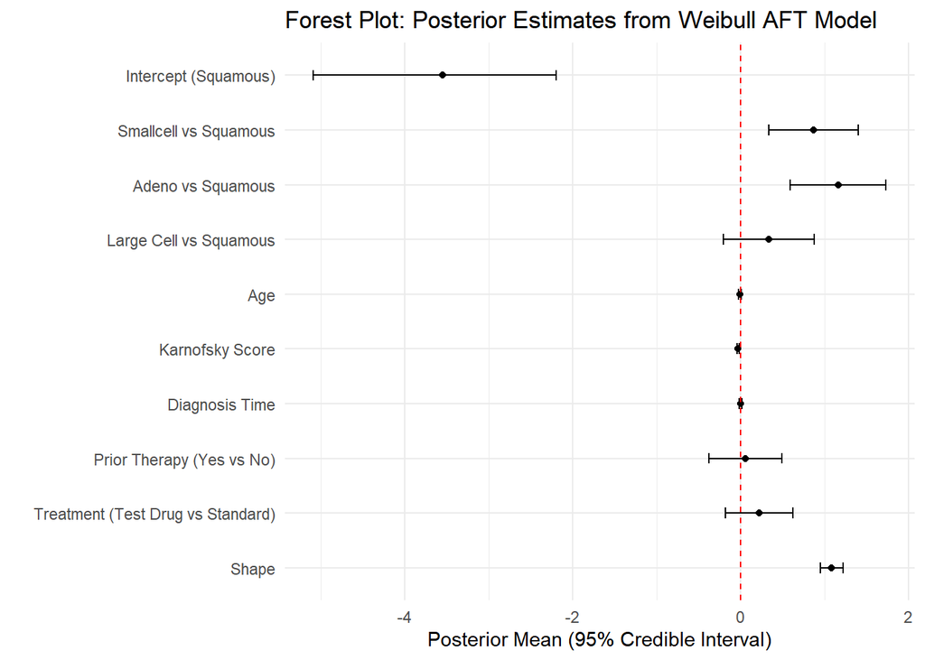

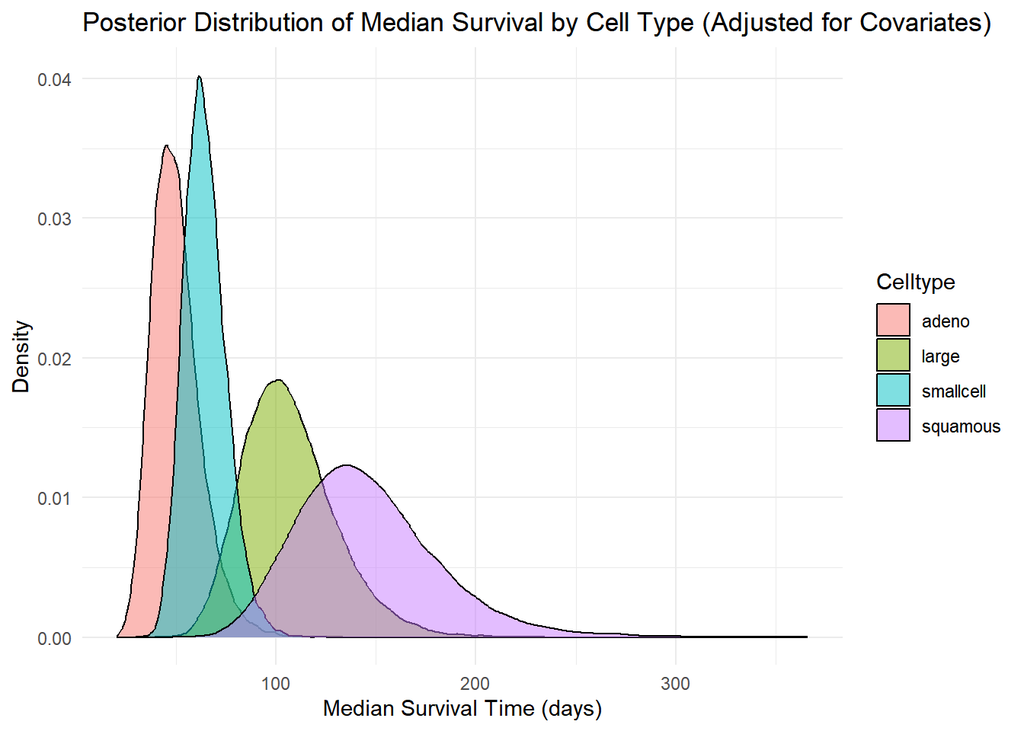

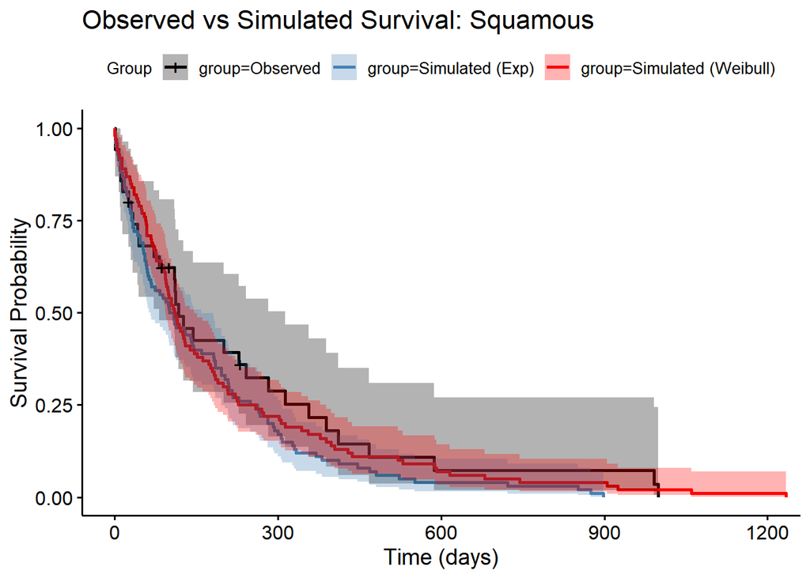

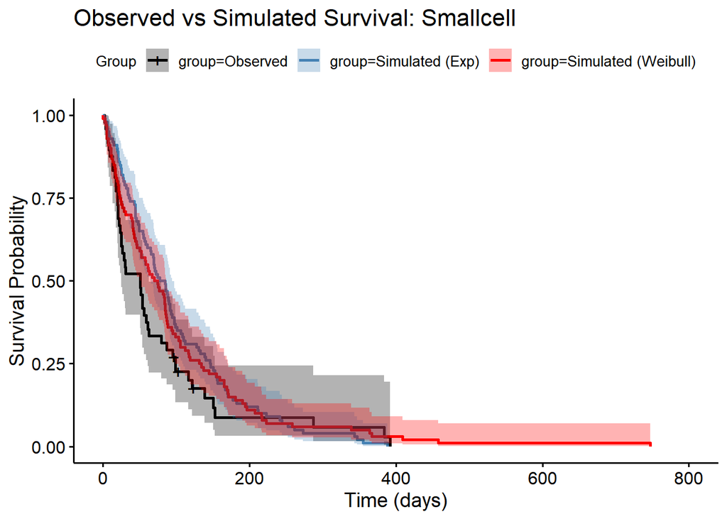

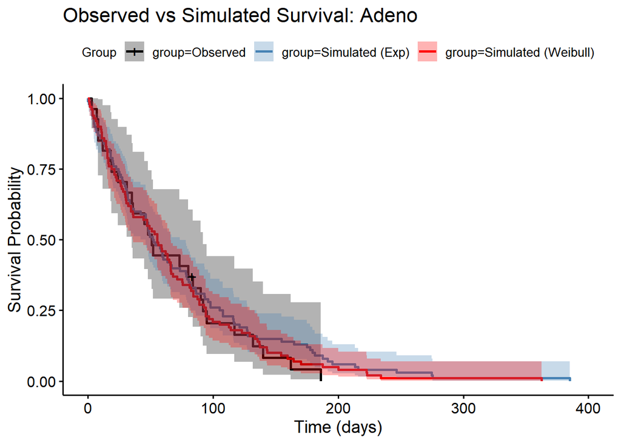

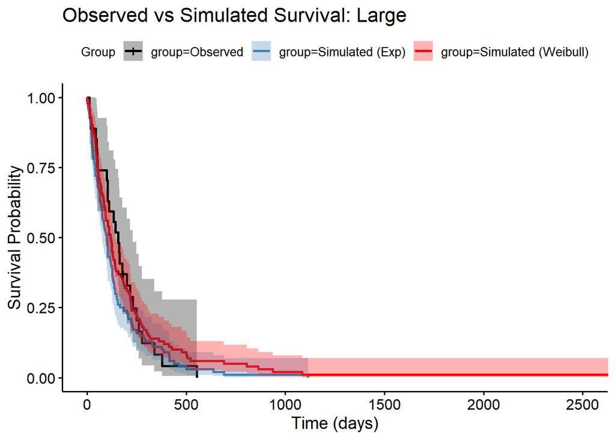

Interpretation by group:

- **Squamous**: Both models capture the general trend, though the Exponential slightly underestimates long-term survival.
- **Smallcell**: The Weibull AFT model shows better alignment with observed survival, especially in early and mid follow-up.
- **Adeno**: The two models behave similarly and fit well, with slightly better alignment by the Weibull in the first 100 days.
- **Large**: Both models tend to underestimate survival; the Exponential AFT over-shrinks long-term survival the most.

```
## Potential scale reduction factors:
##
##         Point est. Upper C.I.
## beta[1]       1.06       1.18
## beta[2]       1.00       1.00
## beta[3]       1.00       1.01
## beta[4]       1.00       1.01
## beta[5]       1.05       1.16
## beta[6]       1.04       1.11
## beta[7]       1.00       1.01
## beta[8]       1.00       1.00
## beta[9]       1.00       1.02
## shape         1.01       1.03
##
## Multivariate psrf
##
## 1.05
```

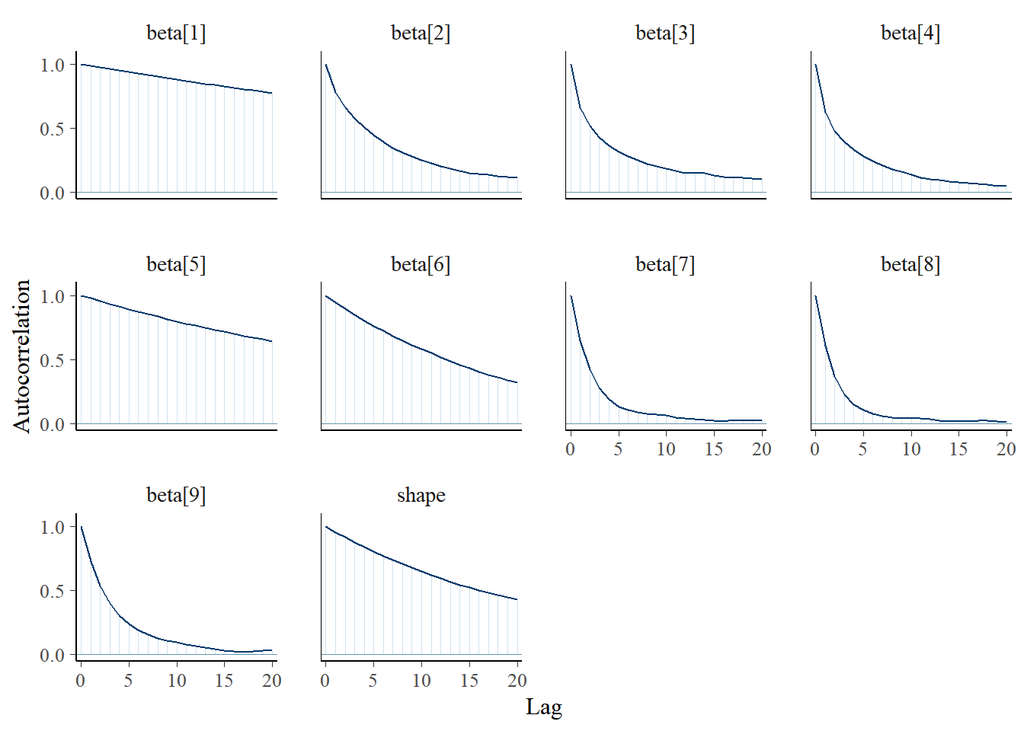

```
##    beta[1]    beta[2]    beta[3]    beta[4]    beta[5]    beta[6]    beta[7]
##   94.79824 1054.24205 1285.11184 1761.91138  177.23360  417.94762 3120.85231
##    beta[8]    beta[9]      shape
## 3667.98679 2085.54149  330.96311
```

```r
#traceplot(samples_weibull_nocensor)

# Output removed to preserve a clean notebook
```

```
## Manual DIC (Weibull AFT with full covariates): 1451.549
```

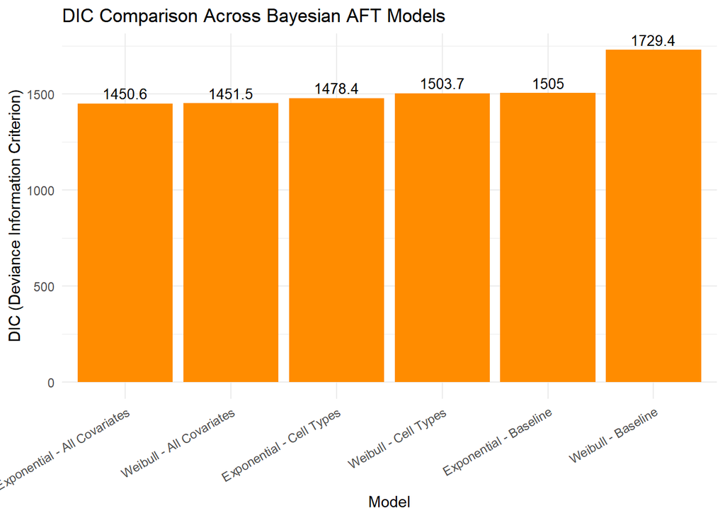

### Posterior-Based Simulation Parameter Recovery

In order to evaluate the reliability and identifiability of the Bayesian Weibull AFT model, we conducted a **parameter recovery experiment**. This simulation-based approach tests whether the Bayesian model, when given synthetic data generated from known parameters, is capable of accurately recovering those same parameters (true values of the regression coefficients and the shape parameter of the Weibull distribution.) via posterior inference.

1. We simulated survival times from a Weibull AFT model using the **posterior means** of our real-data fit as the “true” parameters.
2. We used the same covariate matrix as in the original dataset to generate linear predictors.

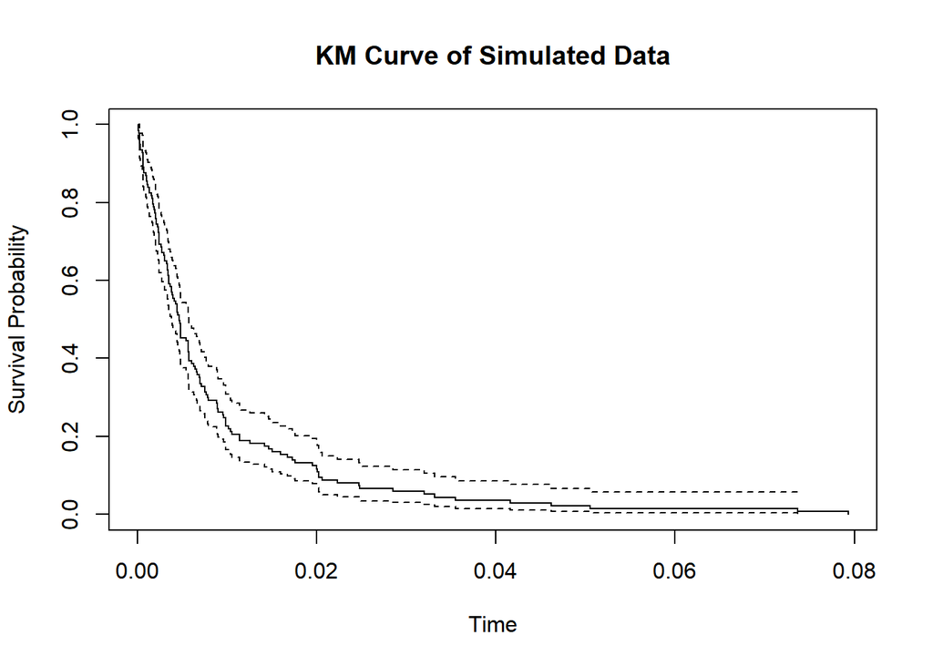

3. We simulated survival times :

In a standard Weibull AFT model, the survival time $T$ follows:

$$T \sim \text{Weibull}(\lambda, \alpha)$$

where:

- $\lambda$ is the scale parameter (depends on covariates via a log-linear link),
- $\alpha$ is the shape parameter.

In AFT form, we instead focus on modeling the logarithm of survival time. The exact Weibull AFT formulation implies that:

$$\log T_i = \mu_i + \sigma \cdot \epsilon_i, \quad \epsilon_i \sim
\text{EV}(0,1)$$

That is, the log-times follow a **Gumbel (Extreme Value Type I)** distribution, not a Normal.

```r
X_sim = model.matrix(~ celltype + age + karno + diagtime + prior + trt, data = sim_data)
#dim(X_sim)

# Log-survival times (AFT model assumes log(T))
log_time = log(sim_data$time)

# Prepare list for JAGS
data_jags_sim = list(
  y = as.numeric(log_time),
  X = X_sim,
  N = nrow(X_sim),
  P = ncol(X_sim)
)
```

However, for the purpose of simulation-based recovery, we adopt a **normal approximation**:

$$\log T_i \sim \mathcal{N}(\mu_i, \sigma^2), \quad \mu_i =
\mathbf{x}_i^\top \boldsymbol{\beta}$$

To allow shape to influence the variability of survival times, we define:

$$\sigma = \frac{1}{\text{shape}} \quad \Rightarrow \quad \tau =
\text{shape}^2$$

where $\tau$ is the precision used in the `dnorm()` distribution in JAGS. This setup allows us to indirectly control the spread of log-times through the `shape` parameter. When `shape = 1`, this corresponds roughly to the exponential model (a special case of Weibull), and the variance of $\log T$ is approximately 1 — close to the variance of the standard Gumbel distribution, $\pi^2/6 \approx 1.645$.

Thus, although this is not the exact Weibull likelihood, it is a **reasonable and tractable approximation** that preserves the key feature: **shape controls log-time variability**. Because the same model is used to simulate and recover the parameters, this approximation does not impair the validity of our recovery experiment.

We fit this model in JAGS using the following structure:

```r
cat("
model {
  for (i in 1:N) {
    y[i] ~ dnorm(mu[i], tau)        # APPROXIMATION: log(T) assumed ~ Normal
    mu[i] = inprod(beta[], X[i, ]) # AFT-style linear predictor
  }

  for (j in 1:P) {
    beta[j] ~ dnorm(0, 0.001)       # Weak prior on regression coefficients
  }

  # Precision (1/variance) of log(T), linked to shape
  tau = pow(1 / shape, 2)          # So SD = 1/shape (=> variance = 1/shape²)
  shape ~ dunif(0.1, 10)            # Weak prior on shape
}
", file = "weibull_nocensor.bug")
```

4. We then fit the **same Bayesian model structure** back to the simulated data using JAGS.

```r
inits = function() {
  list(beta = rep(0, data_jags_sim$P))
}

model_sim = jags.model("weibull_nocensor.bug", data = data_jags_sim, inits = inits, n.chains = 3, n.adapt = 1000)
update(model_sim, 1000)
samples_sim = coda.samples(model_sim, variable.names = c("beta", "shape"), n.iter = 5000)
```

5. Finally, we compared the recovered posterior means to the true values used for simulation.

```
##         Parameter   True Recovered
## beta[1]   beta[1] -3.553    -3.641
## beta[2]   beta[2]  0.867     1.039
## beta[3]   beta[3]  1.161     1.469
## beta[4]   beta[4]  0.333     0.410
## beta[5]   beta[5] -0.007    -0.007
## beta[6]   beta[6] -0.030    -0.036
## beta[7]   beta[7] -0.002    -0.016
## beta[8]   beta[8]  0.058     0.101
## beta[9]   beta[9]  0.219     0.117
## shape       shape  1.082     0.970
```

Overall, the model shows good identifiability and recovery performance, validating the trustworthiness of its application to real-world data.

**95% Credible Interval Coverage Check**:

We assess whether the “true” parameter values used in simulation fall within the 95% credible intervals of the corresponding posterior distributions. This is a more formal test of recovery performance.

```
##         Parameter   True   Mean CI_2.5 CI_97.5 Covered
## beta[1]   beta[1] -3.553 -3.641 -4.811  -2.457     YES
## beta[2]   beta[2]  0.867  1.039  0.600   1.477     YES
## beta[3]   beta[3]  1.161  1.469  0.968   1.971     YES
## beta[4]   beta[4]  0.333  0.410 -0.077   0.905     YES
## beta[5]   beta[5] -0.007 -0.007 -0.023   0.008     YES
## beta[6]   beta[6] -0.030 -0.036 -0.044  -0.027     YES
## beta[7]   beta[7] -0.002 -0.016 -0.033   0.002     YES
## beta[8]   beta[8]  0.058  0.101 -0.307   0.511     YES
## beta[9]   beta[9]  0.219  0.117 -0.220   0.446     YES
## shape       shape  1.082  0.970  0.858   1.097     YES
```

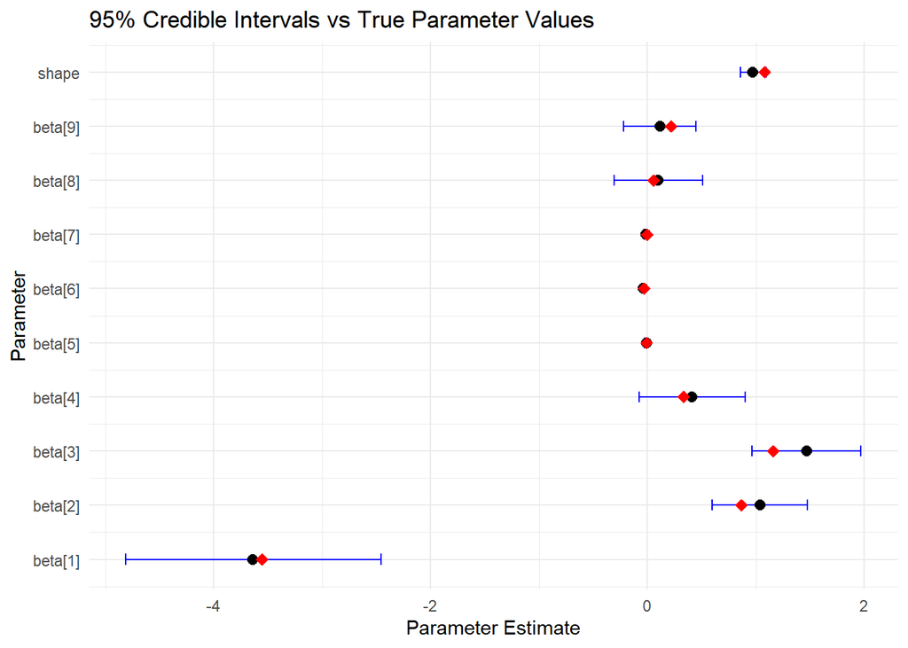

All 10 parameters— were successfully recovered within their 95% Bayesian credible intervals.

This outcome indicates that the model is:

- **Well-calibrated**: the posterior uncertainty is appropriately estimated.
- **Statistically reliable**: there is no evidence of systematic under- or overestimation.
- **Identifiable** under the assumed data-generating process.

```
## [1] 1
```

This confirms that, under ideal conditions (correct model structure and sufficient data), the Bayesian Weibull AFT model is able to recover the true parameters with high accuracy and confidence.

### Pure Simulation-Based Recovery (From Arbitrary Parameters)

To further test the robustness of our Bayesian Weibull AFT model, we conducted a second simulation experiment using **arbitrarily chosen “true” parameter values**. These were selected to reflect realistic and diverse effect sizes based on prior data exploration.

**Simulation setup:**

```r
# Final "true" parameter values chosen based on EDA findings
beta_true2 = c(
  -3.7,    # intercept
   0.6,    # celltype[squamous]
   1.1,    # celltype[smallcell]
   0.3,    # celltype[adeno]
  -0.006,  # age
  -0.035,  # karno
  -0.002,  # diagtime
   0.08,   # prior
   0.18    # trt
)

shape_true2 = 1.5
```

```r
X2 = model.matrix(~ celltype + age + karno + diagtime + prior + trt, data = veteran)
eta2 = X2 %*% beta_true2
lambda2 = exp(eta2)
T_sim2 = rweibull(n = nrow(X2), shape = shape_true2, scale = as.vector(lambda2))
status2 = rep(1, length(T_sim2))
```

We then simulated survival times from the Weibull AFT model

and re-fitted the same Bayesian model using JAGS

```r
# design matrix from sim_data2
X2 = model.matrix(~ celltype + age + karno + diagtime + prior + trt, data = sim_data2)
log_time2 = log(sim_data2$time)

# JAGS data list
data_jags_sim2 = list(
  y = as.numeric(log_time2),
  X = X2,
  N = nrow(X2),
  P = ncol(X2)
)
```

```r
cat("
model {
  for (i in 1:N) {
    y[i] ~ dnorm(mu[i], tau)
    mu[i] = inprod(beta[], X[i, ])
  }

  for (j in 1:P) {
    beta[j] ~ dnorm(0, 0.001)
  }

  tau = pow(1 / shape, 2)
  shape ~ dunif(0.1, 10)
}
", file = "weibull_recovery.bug")
```

```r
inits2 = function() {
  list(beta = rep(0, data_jags_sim2$P))
}

model_sim2 = jags.model("weibull_recovery.bug", data = data_jags_sim2, inits = inits2,
                         n.chains = 3, n.adapt = 1000)
update(model_sim2, 1000)
samples_sim2 = coda.samples(model_sim2, variable.names = c("beta", "shape"), n.iter = 5000)
```

Posterior estimates were compared against the known true values used for simulation.

```
##         Parameter   True Recovered
## beta[1]   beta[1] -3.700    -3.865
## beta[2]   beta[2]  0.600     0.793
## beta[3]   beta[3]  1.100     1.334
## beta[4]   beta[4]  0.300     0.360
## beta[5]   beta[5] -0.006    -0.010
## beta[6]   beta[6] -0.035    -0.035
## beta[7]   beta[7] -0.002    -0.010
## beta[8]   beta[8]  0.080     0.199
## beta[9]   beta[9]  0.180     0.302
## shape       shape  1.500     0.730
```

```
##         Parameter   True   Mean CI_2.5 CI_97.5 Covered
## beta[1]   beta[1] -3.700 -3.865 -4.742  -3.025     YES
## beta[2]   beta[2]  0.600  0.793  0.470   1.117     YES
## beta[3]   beta[3]  1.100  1.334  0.964   1.706     YES
## beta[4]   beta[4]  0.300  0.360 -0.004   0.723     YES
## beta[5]   beta[5] -0.006 -0.010 -0.021   0.002     YES
## beta[6]   beta[6] -0.035 -0.035 -0.041  -0.029     YES
## beta[7]   beta[7] -0.002 -0.010 -0.023   0.003     YES
## beta[8]   beta[8]  0.080  0.199 -0.103   0.499     YES
## beta[9]   beta[9]  0.180  0.302  0.046   0.549     YES
## shape       shape  1.500  0.730  0.647   0.823      NO
```

```
## [1] 0.9
```

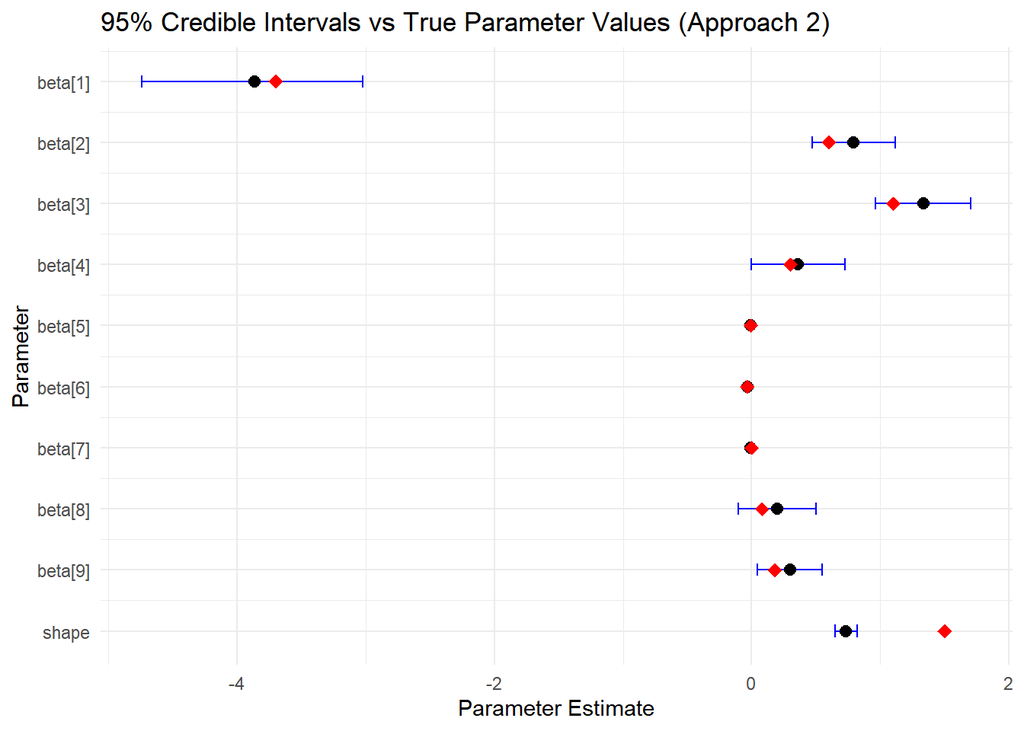

This suggests the model is generally well-calibrated and reliable, even when applied to data simulated under fixed but plausible assumptions.

##### Why the Shape Parameter May Be Harder to Recover

In both simulation-based recovery exercises, we observed that the **Weibull shape parameter** was less precisely estimated than the regression coefficients. In the second experiment (Approach 2), its 95% credible interval did **not** contain the true value, despite all other parameters being well recovered.

Several reasons explain this:

**1. Shape governs the *form* of the hazard function, not just location**

- Regression coefficients shift the location of survival curves for each individual (log-time).
- The **shape parameter**, however, controls the **curvature** of the hazard over time — whether it increases, decreases, or remains constant.
- This global property is harder to learn from noisy or moderately sized data, especially without extreme survival times.

**2. Identifiability is inherently more difficult**

**3. Dependence on tail behavior and time range**

- Estimating the shape accurately often depends on observing **long-term survival** or **extreme values**.
- In our simulated data, while the covariates are varied, **the distribution of survival times is still limited** by the design matrix. This can **reduce the signal** in the tails, which are crucial for identifying shape.

**4. Prior choice and scale**

- We used a **uniform prior** on `shape ~ dunif(0.1, 10)`, which is broad and non-informative.
- In real practice, if prior knowledge suggests a shape near 1–2 (common in medicine), a **more informative prior** could help stabilize inference.

**Conclusion**

While the model successfully recovers regression effects — especially those with moderate to strong influence — the shape parameter requires **larger samples, longer follow-up, or stronger prior information** to be estimated with comparable precision.

### Frequentist Approach

```r
# Fit Weibull AFT using survreg (scale = 1/shape)
frequentist_fit = survreg(Surv(time, status) ~ celltype + age + karno + diagtime + prior + trt,
                           data = veteran, dist = "weibull")

summary(frequentist_fit)
```

```
##
## Call:
## survreg(formula = Surv(time, status) ~ celltype + age + karno +
##     diagtime + prior + trt, data = veteran, dist = "weibull")
##                       Value Std. Error     z       p
## (Intercept)        3.262014   0.662531  4.92 8.5e-07
## celltypesmallcell -0.826185   0.246312 -3.35  0.0008
## celltypeadeno     -1.132725   0.257598 -4.40 1.1e-05
## celltypelarge     -0.397681   0.254749 -1.56  0.1185
## age                0.006099   0.008553  0.71  0.4758
## karno              0.030068   0.004828  6.23 4.7e-10
## diagtime          -0.000469   0.008361 -0.06  0.9553
## prioryes          -0.043898   0.212279 -0.21  0.8362
## trttest           -0.228523   0.186844 -1.22  0.2213
## Log(scale)        -0.074599   0.066311 -1.12  0.2606
##
## Scale= 0.928
##
## Weibull distribution
## Loglik(model)= -715.6   Loglik(intercept only)= -748.1
##  Chisq= 65.08 on 8 degrees of freedom, p= 4.7e-11
## Number of Newton-Raphson Iterations: 6
## n= 137
```

In **Accelerated Failure Time (AFT)** models, the logarithm of survival time $T$ is modeled as:

$$\log(T_i) = \mu_i + \varepsilon_i = \mathbf{x}_i^\top \boldsymbol{\beta}
+ \varepsilon_i$$

where $varepsilon_i$ is a random error term whose distribution depends on the assumed model ( like an Extreme Value for Weibull).

In JAGS, we modeled the Weibull distribution using the parameterization based on the hazard function, where:

This negative sign arises from how JAGS internally defines the scale of the Weibull distribution via the hazard function.

The `survreg()` function in R returns coefficients $\boldsymbol{\beta}_{\text{AFT}}$ from the log-linear AFT model:

$$\log(T_i) = \mathbf{x}_i^\top \boldsymbol{\beta}_{\text{AFT}} +
\varepsilon_i$$

To compare with our Bayesian model in JAGS, which effectively estimates:

$$\log(T_i) = \mathbf{x}_i^\top \boldsymbol{\beta}_{\text{Bayes}} +
\varepsilon_i$$

we must recognize that:

$$\boldsymbol{\beta}_{\text{Bayes}} = -\boldsymbol{\beta}_{\text{AFT
(survreg)}}$$

```
##                 Parameter Bayesian Frequentist
## beta[1]       (Intercept)   -3.553      -3.262
## beta[2] celltypesmallcell    0.867       0.826
## beta[3]     celltypeadeno    1.161       1.133
## beta[4]     celltypelarge    0.333       0.398
## beta[5]               age   -0.007      -0.006
## beta[6]             karno   -0.030      -0.030
## beta[7]          diagtime   -0.002       0.000
## beta[8]          prioryes    0.058       0.044
## beta[9]           trttest    0.219       0.229
## shape               shape    1.082       1.077
```

This step ensures alignment between the Bayesian and frequentist parameter interpretations.

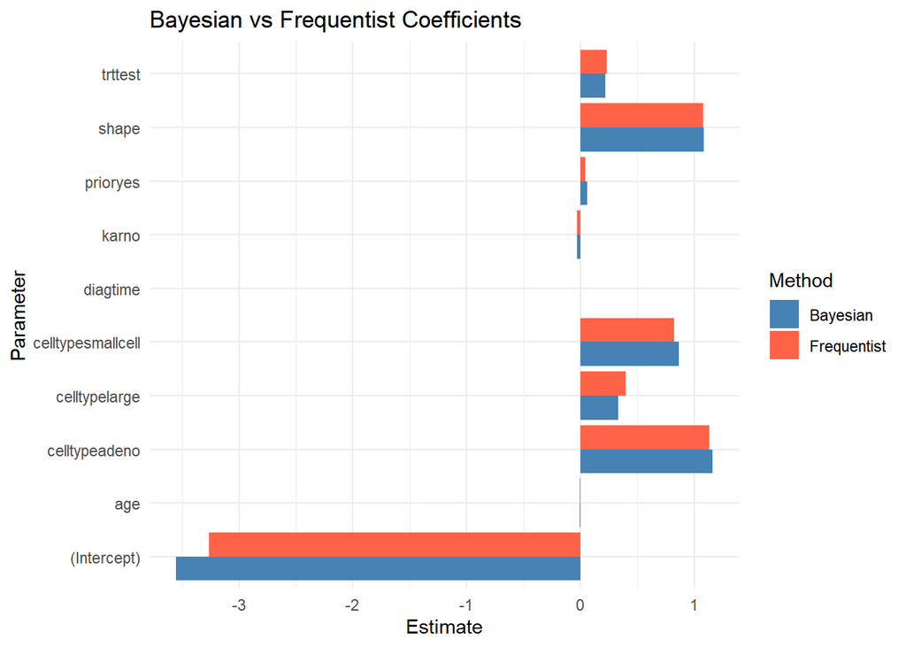

### Frequentist Comparison: Cox Proportional Hazards Model

In addition to the parametric AFT comparison using `survreg()`, we fit a **Cox proportional hazards model** to evaluate the consistency of covariate effects across modeling frameworks.

Unlike the AFT model, the Cox model does not assume a specific baseline distribution for survival times. It models the **hazard function** directly via:

$$h(t \mid \mathbf{x}) = h_0(t) \exp(\mathbf{x}^\top \beta)$$

Here, the coefficients $\beta$ represent **log hazard ratios**:

- A **positive** coefficient implies **higher hazard** (worse survival).
- A **negative** coefficient implies **lower hazard** (longer survival).

This is **the opposite interpretation** compared to AFT models, where **positive β means longer time to event**.

### Cox PH Model Fit, an other Frequentist Approach

The **Cox proportional hazards model** is a widely used **semi-parametric** model for analyzing survival data. It relates the time until an event (e.g., death, failure) to a set of covariates, without requiring the specification of the baseline hazard function, allowing greater flexibility compared to fully parametric models like exponential or Weibull. The model assumes that the hazard ratios between individuals are **constant over time**. That is, the effect of covariates is multiplicative on the hazard and does not vary with time.

The hazard function for individual *i* at time *t* is given by:

$$h_i(t) = h_0(t) \exp(\mathbf{x}_i^\top \boldsymbol{\beta})$$

- $h_i(t)$: Hazard for individual *i* at time *t*.
- $h_0(t)$: **Baseline hazard**, common to all individuals (left unspecified).
- $\mathbf{x}_i$: Vector of covariates for individual *i*.
- $\boldsymbol{\beta}$: Vector of regression coefficients to be estimated.

Inference on $\boldsymbol{\beta}$ is done via **partial likelihood**, which eliminates the need to estimate $h_0(t)$.

**Interpretation**:

- The coefficient $\beta_j$ corresponds to a **log hazard ratio**.
- The exponentiated coefficient $\exp(\beta_j)$ is the **hazard ratio** associated with a one-unit increase in the covariate $x_j$.
  - $\exp(\beta_j) > 1$: increased hazard (shorter survival).
  - $\exp(\beta_j) < 1$: decreased hazard (longer survival).
- There is **no intercept term** because the baseline hazard is left unspecified.

The Cox model is especially powerful when the proportional hazards assumption holds and the goal is to assess the relative effects of covariates on event risk over time.

```r
cox_fit = coxph(Surv(time, status) ~ celltype + age + karno + diagtime + prior + trt,
                 data = veteran)

summary(cox_fit)
```

```
## Call:
## coxph(formula = Surv(time, status) ~ celltype + age + karno +
##     diagtime + prior + trt, data = veteran)
##
##   n= 137, number of events= 128
##
##                         coef  exp(coef)   se(coef)      z Pr(>|z|)
## celltypesmallcell  8.616e-01  2.367e+00  2.753e-01  3.130  0.00175 **
## celltypeadeno      1.196e+00  3.307e+00  3.009e-01  3.975 7.05e-05 ***
## celltypelarge      4.013e-01  1.494e+00  2.827e-01  1.420  0.15574
## age               -8.706e-03  9.913e-01  9.300e-03 -0.936  0.34920
## karno             -3.282e-02  9.677e-01  5.508e-03 -5.958 2.55e-09 ***
## diagtime           8.132e-05  1.000e+00  9.136e-03  0.009  0.99290
## prioryes           7.159e-02  1.074e+00  2.323e-01  0.308  0.75794
## trttest            2.946e-01  1.343e+00  2.075e-01  1.419  0.15577
## ---
## Signif. codes:  0 '***' 0.001 '**' 0.01 '*' 0.05 '.' 0.1 ' ' 1
##
##                   exp(coef) exp(-coef) lower .95 upper .95
## celltypesmallcell    2.3669     0.4225    1.3799    4.0597
## celltypeadeno        3.3071     0.3024    1.8336    5.9647
## celltypelarge        1.4938     0.6695    0.8583    2.5996
## age                  0.9913     1.0087    0.9734    1.0096
## karno                0.9677     1.0334    0.9573    0.9782
## diagtime             1.0001     0.9999    0.9823    1.0182
## prioryes             1.0742     0.9309    0.6813    1.6937
## trttest              1.3426     0.7448    0.8939    2.0166
##
## Concordance= 0.736  (se = 0.021 )
## Likelihood ratio test= 62.1  on 8 df,   p=2e-10
## Wald test            = 62.37  on 8 df,   p=2e-10
## Score (logrank) test = 66.74  on 8 df,   p=2e-11
```

- **Cell type** plays a substantial role:
  - Patients with **smallcell tumors** have 2.37× higher hazard of death compared to the reference group (squamous), *p = 0.00175*.
  - **Adeno** type is associated with the **highest hazard** (HR = 3.31, *p < 0.001*).
  - **Large cell** type has elevated hazard (HR = 1.49), but this is *not statistically significant* (*p = 0.16*).
- **Karnofsky performance score (karno)** has a significant **protective effect**:
  - Each 1-unit increase reduces hazard by ~3.3% (HR = 0.9677, *p < 0.001*).
- **Age, diagnosis time, prior therapy**, and **treatment type** do not reach significance at the 5% level, although `trttest` shows a mild trend (HR = 1.34, *p = 0.16*).
- **Model Fit**:
  - Concordance index = **0.736**, indicating good predictive discrimination.
  - All three global tests (Likelihood Ratio, Wald, Logrank) are **highly significant (p < 0.001)**, suggesting the model fits well overall.

```
##                           Parameter Bayesian Frequentist Cox_PH
## (Intercept)             (Intercept)   -3.553      -3.262     NA
## celltypesmallcell celltypesmallcell    0.867       0.826  0.862
## celltypeadeno         celltypeadeno    1.161       1.133  1.196
## celltypelarge         celltypelarge    0.333       0.398  0.401
## age                             age   -0.007      -0.006 -0.009
## karno                         karno   -0.030      -0.030 -0.033
## diagtime                   diagtime   -0.002       0.000  0.000
## prioryes                   prioryes    0.058       0.044  0.072
## trttest                     trttest    0.219       0.229  0.295
```

The Cox Proportional Hazards model does **not include an intercept term**. This is because it estimates relative hazard ratios using **partial likelihood**, which cancels out the **baseline hazard function** $h_0(t)$. As a result, any constant offset (intercept) is not separately estimable and is absorbed into the baseline.

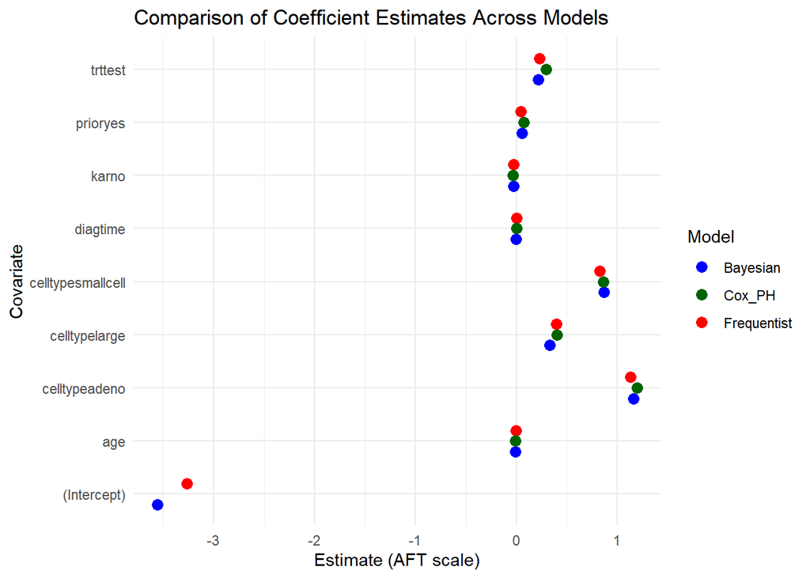